# Homework 3

Steve Harms

February 17, 2019

1. Let $X_{1}, \ldots, X_{n}$ be independent identically distributed (i.i.d.) $p$-dimensional random vectors from $N(\mu, \Sigma)$. Let $C = (c_{i_1i_2})$ be an $n \times n$ orthogonal matrix. Let
   $$Y = \begin{pmatrix} Y_{1}^{\prime} \\ \vdots \\ Y_{n}^{\prime} \end{pmatrix} = C \begin{pmatrix} X_{1}^{\prime} \\ \vdots \\ X_{n}^{\prime} \end{pmatrix}.$$

**(a)** $Y_{i_1} \sim N(v_{i_1}, \Sigma)$ for $v_{i_1} = \sum_{i_2 = 1}^{n} c_{i_1i_2} \mu_{i_2}$;

Note that by our specification of C, we have that $Y_{i_1}$ is a linear combination of i.i.d. MVN vectors, and thus $Y_{i_1}$ is MVN as well. Next, we have that $Y_{i_1} = C_{i_1,\cdot}\cdot\begin{pmatrix} X_{1}^{\prime} \\ \vdots \\ X_{n}^{\prime} \end{pmatrix}$, thus the mean of $Y_{i_1}$ is just the inner product of the elements of the $i_1$th row of C and $\begin{pmatrix} X_{1}^{\prime} \\ \vdots \\ X_{n}^{\prime} \end{pmatrix}$, which is just $v_{i_1} = \sum_{i_2 = 1}^{n} c_{i_1i_2} \mu_{i_2}$. For the covariance matrix, we have that $Var(Y_{i_1}) = Var(C_{i_1,\cdot}]\cdot\begin{pmatrix} X_{1}^{\prime} \\ \vdots \\ X_{n}^{\prime} \end{pmatrix}) = C_{i_1,\cdot}'C_{i_1,\cdot}\cdot Var(X) = Var(X) = \Sigma$ because the $X_i$s are i.i.d. and $C$ is orthogonal and thus cancels to the identity matrix.

**(b)** $Y_{i_1}$ and $Y_{i_2}$ are independent for $i_1 \neq i_2$;

Let $Y_{i_1} = C_{i_1,\cdot}*X$ and $Y_{i_2}= C_{i_2,\cdot}*X$, for $i_1 \neq i_2$. Note that both $Y_{i_1}$ and $Y_{i_2}$ are multivariate normal with the same covariance matrix $\Sigma$ by the result in (a). Furthermore, we can combine $Y_{i_1}$ and $Y_{i_2}$ into a partitioned vector $Y_{i} = \begin{pmatrix} Y_{i_1} \\ \cdots \\ Y_{i_2} \end{pmatrix} = \begin{pmatrix} C_{i_1} \\ \cdots \\ C_{i_2} \end{pmatrix} \cdot X' = C_i \cdot X'$ that is also multivariate normal. Then the covariance of this new partitioned vector is $Var(Y_i) = C_i \Sigma C_i'$. By the orthogonality of $C$ and our partitioning of $Y_i$, we have that $Cov(Y_{i_1},Y_{i_2}) = \sum_{j=1}^{n}C_{i_1,j}C_{j,i_2}X' = 0$, because orthogonality implies that inner products of the columns of $C$ are 0 for $i_1 \neq i_2$. Because the covariance is $0$, $Y_{i_1}$ and $Y_{i_2}$ are independent.

**(c)** $\sum_{i = 1}^{n} Y_{i} Y_{i}^{\prime} = \sum_{i = 1}^{n} X_{i} X_{i}^{\prime}$.

Again, this result follows from the orthogonality of $C$. We have
$$\sum_{i = 1}^{n} Y_{i} Y_{i}^{\prime} = \sum_{i = 1}^{n} C\cdot X_{i} (C\cdot X_{i})^{\prime} = \sum_{i = 1}^{n} CC^{\prime}\cdot X_{i}\cdot X_{i}^{\prime} = \sum_{i = 1}^{n}X_{i}\cdot X_{i}^{\prime}.$$

**[For all of the above results, we could also look at Result 4.8 in the textbook]**

**2.** Let $X_{1}, \ldots, X_{n}$ be i.i.d. **univariate** random variables from $N(\mu, \sigma^{2})$.

**(a)** Provide the conditional distribution of $X_{1}, \ldots, X_{n - 1}$ given $\bar{X}$

Note that because $\bar{X}$ is a linear combination of i.i.d. normal r.v.s, it is also normal. We know by independence of $X_i$s that $Cov(X_i, \bar{X}) = \frac{1}{n}Var(X_i) = \frac{\sigma^2}{n}$. Then we can create a partitioned random vector $(X_{1}, \ldots, X_{n - 1} \vdots \bar{X})'$ that has mean vector $\mu$ and a covariance matrix with the upper (n-1)x(n-1) block being $\sigma^2 \cdot I$ and the rest of the covariance matrix (row n and column n) having elements all equal to $Cov(X_i,\bar{X}) = Var(\bar{X}) = \sigma^2/n$. Then the conditional distribution, using slide 141 from the lecture notes, is $\boldsymbol{X}|\bar{X} \sim N(\mu_{X|\bar{X}},\Sigma_{X|\bar{X}})$ where $\mu_{X|\bar{X}} = \boldsymbol{\mu} + (\sigma^2/n)(\sigma^2/n)^{-1}(\bar{X}-\mu) = \boldsymbol{\mu} + (\bar{X}-\mu) = \boxed{\bar{X}}$ and $\Sigma_{X|\bar{X}} = \sigma^2\cdot I_{n-1} - (\sigma^2/n)\cdot 1_{n-1} \cdot (\sigma^2/n)^{-1} \cdot (\sigma^2/n)\cdot 1_{n-1}' = \boxed{\sigma^2\cdot I_{n-1} - (\sigma^2/n)\cdot 1_{n-1}1_{n-1}'}$.

**(b)** Write a function in R which will generate a random vector $X = (X_{1}, \ldots, X_{n - 1}, X_{n})$ given $\bar{X}$. (Note that $X_{n} = n \bar{X} - \sum_{i = 1}^{n - 1} X_{i}$.)

```r
library(MASS)
conditionalnorm <- function(n, xbar, sigmasq, method="cholesky"){
  #generate mean vector
  muv <- rep(xbar, times = n-1)
  #generate covariance matrix
  sigmav <- sigmasq*diag(n-1) - sigmasq/n*matrix(1,nrow=n-1,ncol=n-1)
  #get cholesky decomposition of the covariance matrix
  C<- chol(sigmav)
  #use cholesky to get samples from MVN conditional distribution
  rs <- rnorm(n-1)
  newrs <- muv + t(C)%*%rs
  #we could also just use mvrnorm() from MASS library which uses eigendecomposition
  if(method=="eigen"){
  newrs <- mvrnorm(1,mu=muv,Sigma=sigmav)
  }
  #attach Xn to X1,...,Xn-1
  newrs <- c(newrs, n*xbar-sum(newrs))
  return(newrs)
}

test <- conditionalnorm(n=10,xbar=10,sigmasq=3)
test
```

```
##  [1] 10.971104  8.147984  8.867709 11.629789 12.687983  7.617646 10.718808
##  [8] 10.299973  9.798681  9.260323
```

```r
var(test)
```

```
## [1] 2.489609
```

**(c)** Suppose we have a $16 \times 16$ matrix $A$ which is averaged in each of the $4 \times 4$ non-overlapping blocks, resulting a $4 \times 4$ matrix $B$. Based on the result from (b), write a function to predict the original matrix $A$. Try your function on a setting of specific $B$ and $\sigma^{2}$. I use the matrix “b” to test below, with $\sigma^2 = 2$

```r
library(tidyverse); library(plyr)
#function
recovermat <- function(B,sigmasq,method="cholesky"){
  #generate mvn for each element in B
  b <- c(B)
  alist <- alply(b, .margins=1,.fun=conditionalnorm, n=4, sigmasq=sigmasq, method=method) %>%
    llply(.fun=matrix, nrow=2,ncol=2)
  #reassmble
  outmat <- rbind(cbind(alist[[1]],alist[[3]]),cbind(alist[[2]],alist[[4]]))
  return(outmat)
}

b <- matrix(c(3,8,35,19),nrow=2,ncol=2)
b
```

```
##      [,1] [,2]
## [1,]    3   35
## [2,]    8   19
```

```r
#using cholesky factorization
recovermat(b,sigmasq=2,method="cholesky")
```

```
##          [,1]     [,2]     [,3]     [,4]
## [1,] 2.283157 4.583200 34.39996 33.60563
## [2,] 1.970450 3.163193 35.00868 36.98572
## [3,] 7.162051 7.294915 16.13788 21.16507
## [4,] 9.973197 7.569836 20.30068 18.39637
```

```r
#using mvnorm()
recovermat(b,sigmasq=2, method="eigen")
```

```
##          [,1]     [,2]     [,3]     [,4]
## [1,] 4.007228 2.076498 34.89455 36.06250
## [2,] 2.116375 3.799899 34.56177 34.48118
## [3,] 7.250512 8.857952 19.69037 18.67270
## [4,] 7.972064 7.919473 19.49885 18.13808
```

**It looks like the function does a decent job of simulating a possible matrix A.**

**3.**

**(a)** Use `QQplot.normal` function in the code and `ggplot` to make quantile plots for each of the four variables. Use `facet` option to put them in one plot.

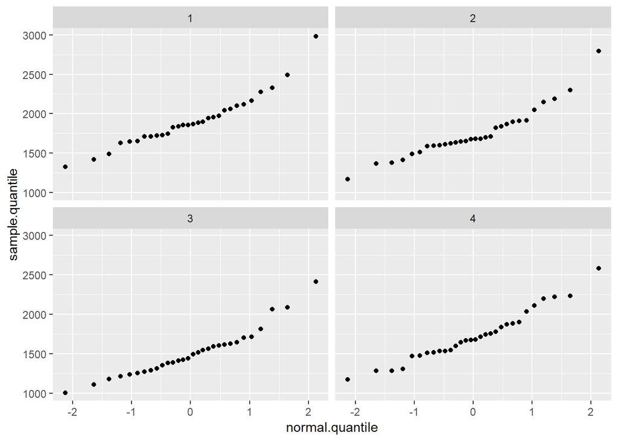

```r
# Normal Q-Q plot
library(ggplot2)
X = read.table("board.stiffness.dat", head = FALSE)

QQplot.normal = function(x){
  # x is an observed vector of a variable
  x.sort = sort(x)
  n = length(x)
  p = ( c(1 : n) - 0.5 ) / n
  q = qnorm(p)
  res = data.frame(cbind(x.sort, q))
  names(res) = c("sample.quantile", "normal.quantile")
  return(res)
}

QQs <- apply(X[,-1],2,FUN=QQplot.normal) %>% as.data.frame()
QQs <- data.frame(sample.quantile = gather(QQs[,c(1,3,5,7)])[,2], normal.quantile=gather(QQs[,c(2,4,6,8)])[,2],
                  Sample = as.factor(rep(1:4,each=30)))
ggplot(data = QQs) + geom_point(aes(x=normal.quantile, y=sample.quantile)) + facet_wrap(.~Sample)
```

**The QQplots look similar for each variable. All look to be approximately normal. Variable 2 (and possibly 4) look slightly flatter in the middle, but overall each variable looks approximately normal. Variable 1 is curved for the last few observations as well, indicating possible outliers.**

**(b)** Write a function to conduct Chi-square quantile plot. Implement this function on this dataset.

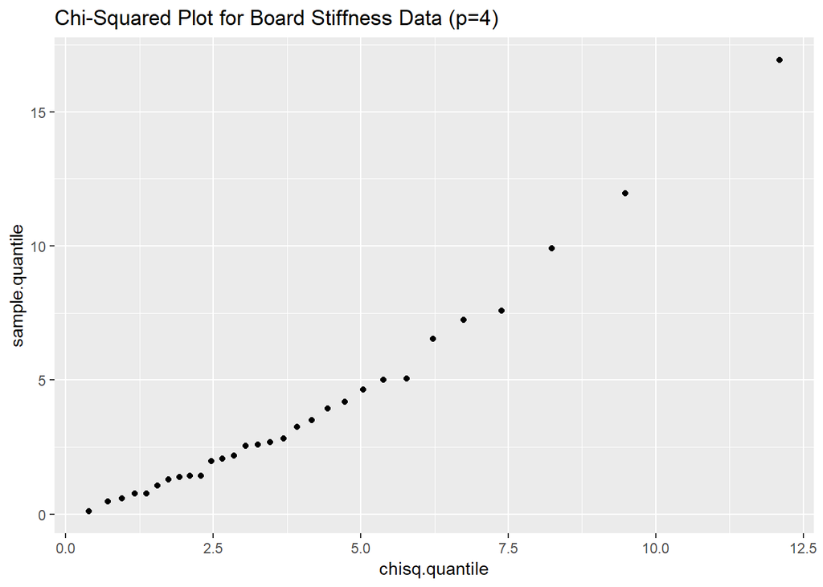

```r
chisqplot <- function(x){
  # x is an observed vector of a variable
  #get sample statistics
  xbar <- apply(x,2,mean); s <- cov(x)
  #get squared distances from x
  dis <- mahalanobis(x, center=xbar, cov=s)
  #sort
  di.sort = sort(dis)
  #get chi-squared quantiles
  n = nrow(x)
  p = ( c(1 : n) - 0.5 ) / n
  q = qchisq(p,df=ncol(x))
  #combine and output
  res = data.frame(cbind(di.sort, q))
  names(res) = c("sample.quantile", "chisq.quantile")
  return(res)
}

chisqs <- chisqplot(X[,-1])
ggplot(data=chisqs) + geom_point(aes(x=chisq.quantile,y=sample.quantile)) + ggtitle("Chi-Squared Plot for Board Stiffness Data (p=4)")
```

**Visually, the plot does not appear to be a straight line in the tail (i.e., we may have outliers). However, ethe smaller quantiles (observations 1-25) do appear to be approximately on a line, indicating that the observations may come from a multivariate normal distribution.**

**(c)** Based on the fucntion `testnormality` in the code, conduct random projection based shapiro-wilks test for multivariate data.

```r
set.seed(11235)
testnormality <- function(X, numproj = 100000)
{
  p = ncol(X)
  n = nrow(X)
  x <- matrix(rnorm(numproj * p), nrow = p)
  y <- matrix(sqrt(apply(x^2, 2, sum)), nrow = p, ncol = numproj, by = T)

  z <- x / y

  tempdat <- as.matrix(X) %*% z  # this gives rise to a p x numproj matrix
  # called tempdat here

  # perform Shapiro-Wilks' test and calculate individual p-values on each of
  # the numproj observation sets.

  pvals <- as.numeric(matrix(unlist(apply(tempdat, 2, shapiro.test)),
                             ncol=4, by = T)[,2])
  return(min(pvals)) #returns the smallest p-value among all projections
}

testnormality(X[,-1])
```

```
## [1] 7.176158e-06
```

**(d)** Use parametric bootstrap to determine the reject region of the test. **We can us a small loop to generate 1000 bootstrap replicates and then get the p-value for them**

```r
boots <- c()
i=0
bootsize = 1000
repeat{
  i=i+1
  boots[i] <- testnormality(X[,-1], numproj=10000)
  if(i==bootsize){break}
}
```

**Then we can determine the rejection region. For a size $\alpha=.05$ test, we can use the 5th percentile of the bootstrap p-value empirical distribution**

```r
boots %>% quantile(probs=.05)
```

```
##           5%
## 7.276892e-06
```

**Thus we reject the null hypothesis for any p-value less than $7.276892 x 10^{-6}$.** **Should we reject the null hypothesis for this data?**

```r
as.numeric(matrix(unlist(apply(X[,-1], 2, shapiro.test)),ncol=4, by = T)[,2])
```

```
## [1] 0.05264556 0.01746190 0.05750619 0.33371933
```